# Assignment 4

2026-05-18

### Task One

Sequencing technologies introduce technical variability. Therefore, raw transcriptomic data mus be adjusted to account for these technical factors before researchers can sompare gene expression within or between samples. Three stages of Normalization:

*Within sample:* Reguired to compare the expression of genes within an individual sample. Adjusting for the transcript length and sequencing depth Longer genes have more mapped reads at the same expression level and number of sequencing reads per sample may vary

*Between samples:* to adjust for technical variations like sequencing depth if the transcript population changes, it affects the relative levels of transcripts/ expression of a gene, even if the absolut expression of this gene stays the same

*Across dataset:* to correct batch effects between datasets

**CPM (Counts per million):** Number of raw reads mapped to a transcript, scaled by the number of sequencing reads in the sample (divided by the total number of reads in a sample), multiplied by a million. Normalizes for sequencing depth but not for gene length unsuitable for within sample comparison between sample comparison can be made, but only within a dataset –> useful to compare how many reads a gene got relative to the total number of reads in that sample

Tools that use CPM: edgeR limma-voom Single-cell QC tools (Scater) can be used in DESeq2 for QC and visualization

### Task Two

```r
counts_df <- read.csv("basic_yeast_heatshock.csv", header = TRUE, stringsAsFactors = FALSE)
gtf <- read.table("annotation.gtf", sep = "\t", header = FALSE, comment.char = "#", stringsAsFactors = FALSE)
head(gtf)
```

```
##   V1             V2          V3   V4   V5 V6 V7 V8
## 1 IV protein_coding        gene 1802 2953  .  +  .
## 2 IV protein_coding  transcript 1802 2953  .  +  .
## 3 IV protein_coding        exon 1802 2953  .  +  .
## 4 IV protein_coding         CDS 1802 2950  .  +  0
## 5 IV protein_coding start_codon 1802 1804  .  +  0
## 6 IV protein_coding  stop_codon 2951 2953  .  +  0
##                                                                                                                                                                                              V9
## 1                                                                                                            gene_id YDL248W; gene_name COS7; gene_source ensembl; gene_biotype protein_coding;
## 2                                    gene_id YDL248W; transcript_id YDL248W; gene_name COS7; gene_source ensembl; gene_biotype protein_coding; transcript_name COS7; transcript_source ensembl;
## 3  gene_id YDL248W; transcript_id YDL248W; exon_number 1; gene_name COS7; gene_source ensembl; gene_biotype protein_coding; transcript_name COS7; transcript_source ensembl; exon_id YDL248W.1;
## 4 gene_id YDL248W; transcript_id YDL248W; exon_number 1; gene_name COS7; gene_source ensembl; gene_biotype protein_coding; transcript_name COS7; transcript_source ensembl; protein_id YDL248W;
## 5                     gene_id YDL248W; transcript_id YDL248W; exon_number 1; gene_name COS7; gene_source ensembl; gene_biotype protein_coding; transcript_name COS7; transcript_source ensembl;
## 6                     gene_id YDL248W; transcript_id YDL248W; exon_number 1; gene_name COS7; gene_source ensembl; gene_biotype protein_coding; transcript_name COS7; transcript_source ensembl;
```

```r
genes_gtf <- gtf[gtf$V3 == "gene", ] # filtert alle Spalten mit "gene" und behält alle Spalten davon
genes_length <- genes_gtf$V5 - genes_gtf$V4 + 1 # berechnet die Länge des genoms

gene_id_part <- sapply(strsplit(genes_gtf$V9, ";"), `[`, 1) # gene_id + ID filtern
genes_id <- gsub("gene_id ", "", gene_id_part) # genes_id durch nichts ersetzen --> nur die ID übrig lassen (wie in csv datei)
head(genes_id)
```

```
## [1] "YDL248W"   "YDL247W-A" "YDL247W"   "YDL246C"   "YDL245C"   "YDL244W"
```

```r
lengths_table <- data.frame(
  gene_id = genes_id,
  length = genes_length,
  stringsAsFactors = FALSE
) # table with id and gene length
head(lengths_table)
```

```
##     gene_id length
## 1   YDL248W   1152
## 2 YDL247W-A     75
## 3   YDL247W   1830
## 4   YDL246C   1074
## 5   YDL245C   1704
## 6   YDL244W   1023
```

```r
counts_with_length <- merge(counts_df, lengths_table, by = "gene_id") # merging both tables with at the key word -> one big table with the counts per condition and the genelength
head(counts_with_length)
```

```
##    gene_id X25_0_r1 X25_0_r2 X25_0_r3 X42_10_r1 X42_10_r2 X42_10_r3 X42_30_r1
## 1 15S_rRNA        2        0        5         0         2         0         1
## 2 21S_rRNA       79       18       33        50        11        12        27
## 3     HRA1        0        0        1         5         2         4         3
## 4     ICR1      105      154      215       208       159       162       297
## 5     LSR1       51        8        9         8        12        12        39
## 6     NME1       23       10       15       172        43        74       104
##   X42_30_r2 X42_30_r3 length
## 1         2         1   1649
## 2        67        33   4439
## 3         5         8    564
## 4       495       418   3199
## 5        43        58   1175
## 6       188       161    340
```

```r
count_matrix <- as.matrix(counts_with_length[, 2:10]) # matrix for easier calculations
rownames(count_matrix) <- counts_with_length$gene_id
genes_length <- counts_with_length$length

library_sizes <- colSums(count_matrix)

cpm_matrix <- t(t(count_matrix) / library_sizes) * 1000000

rpkm_matrix <- count_matrix * 10^9
for(i in 1:ncol(rpkm_matrix)){
  rpkm_matrix[, i] <- rpkm_matrix[, i] / (genes_length * library_sizes[i])
}

head(cpm_matrix)
```

```
##           X25_0_r1  X25_0_r2   X25_0_r3  X42_10_r1  X42_10_r2  X42_10_r3
## 15S_rRNA  0.349382  0.000000  0.6236979  0.0000000  0.5101201  0.0000000
## 21S_rRNA 13.800590  3.398930  4.1164060  7.7705922  2.8056608  2.0499522
## HRA1      0.000000  0.000000  0.1247396  0.7770592  0.5101201  0.6833174
## ICR1     18.342556 29.079736 26.8190086 32.3256637 40.5545516 27.6743548
## LSR1      8.909242  1.510636  1.1226562  1.2432948  3.0607209  2.0499522
## NME1      4.017893  1.888295  1.8710936 26.7308373 10.9675831 12.6413720
##           X42_30_r1  X42_30_r2  X42_30_r3
## 15S_rRNA  0.1780649  0.3105190  0.1752245
## 21S_rRNA  4.8077522 10.4023876  5.7824090
## HRA1      0.5341947  0.7762976  1.4017961
## ICR1     52.8852746 76.8534609 73.2438473
## LSR1      6.9445310  6.6761592 10.1630219
## NME1     18.5187493 29.1887892 28.2111469
```

```r
head(rpkm_matrix)
```

```
##            X25_0_r1  X25_0_r2  X25_0_r3 X42_10_r1  X42_10_r2 X42_10_r3
## 15S_rRNA  0.2118751 0.0000000 0.3782279  0.000000  0.3093512  0.000000
## 21S_rRNA  3.1089412 0.7656973 0.9273273  1.750528  0.6320479  0.461805
## HRA1      0.0000000 0.0000000 0.2211695  1.377765  0.9044683  1.211556
## ICR1      5.7338406 9.0902582 8.3835601 10.104928 12.6772590  8.650939
## LSR1      7.5823332 1.2856473 0.9554521  1.058123  2.6048688  1.744640
## NME1     11.8173331 5.5538075 5.5032165 78.620110 32.2575975 37.180506
##           X42_30_r1  X42_30_r2  X42_30_r3
## 15S_rRNA  0.1079836  0.1883075  0.1062611
## 21S_rRNA  1.0830710  2.3434079  1.3026378
## HRA1      0.9471537  1.3764142  2.4854541
## ICR1     16.5318145 24.0242141 22.8958572
## LSR1      5.9102392  5.6818376  8.6493803
## NME1     54.4669098 85.8493800 82.9739616
```

### Task Three

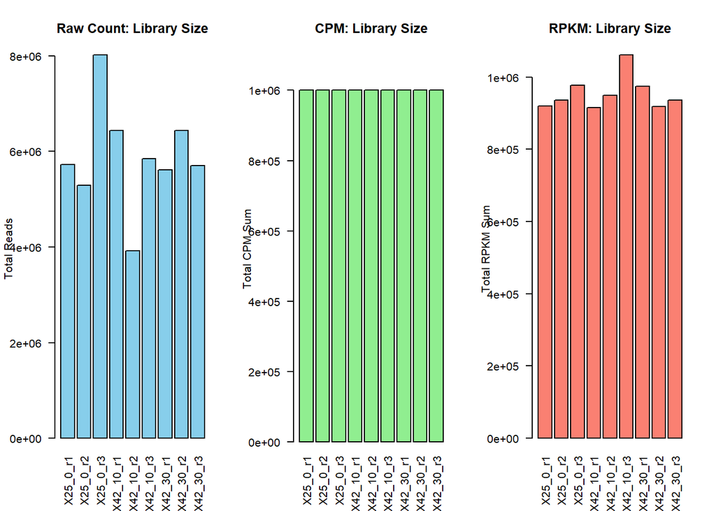

```r
par(mfrow = c(1,3))

barplot(colSums(count_matrix),
        col = "skyblue",
        main = "Raw Count: Library Size",
        ylab = "Total Reads",
        las = 2)

barplot(colSums(cpm_matrix),
        col = "lightgreen",
        main = "CPM: Library Size",
        ylab = "Total CPM Sum",
        las = 2,
        ylim = c(0, 1100000)) # adjusting the scale for better visualization

barplot(colSums(rpkm_matrix),
        col = "salmon",
        main = "RPKM: Library Size",
        ylab = "Total RPKM Sum",
        las = 2)
```

*Raw Counts:* the plot shows the total number of sequenced reads per condition. It reveals technical variance (= batch effects) with varying sequencing depths throughout the different samples under the same condition.

*CPM:* The normalization scales the sum to exactly 1 000 000. The technical variance is eliminated, the samples are on the same scale

*RPKM:* The columns are not the same height caused by the division of the individual genen by its length. The variation represents the biological differences in gene length expression

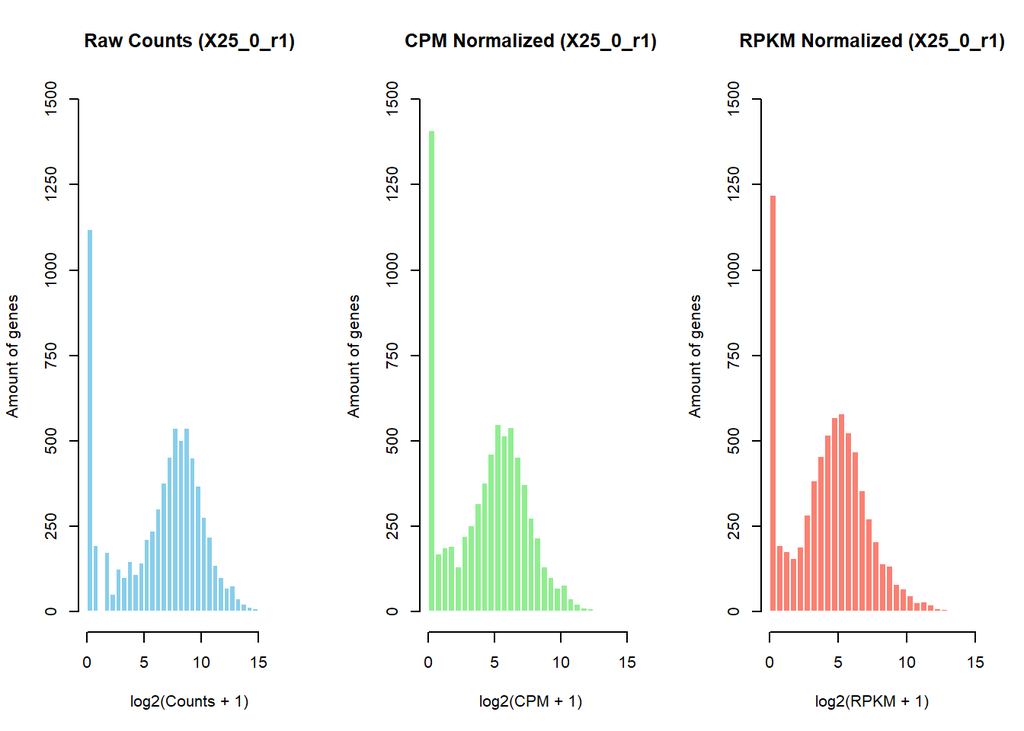

```r
par(mfrow = c(1,3))

hist(log2(count_matrix[, "X25_0_r1"] + 1),
     breaks = 50,
     col = "skyblue",
     border = "white",
     main = "Raw Counts (X25_0_r1)",
     xlab = "log2(Counts + 1)",
     ylab = "Amount of genes",
     ylim = c(0,1500),
     yaxt = "n")
axis(side =2, at = seq(0, 1500, by = 250))

hist(log2(cpm_matrix[, "X25_0_r1"] + 1),
     breaks = 50,
     col = "lightgreen",
     border = "white",
     main = "CPM Normalized (X25_0_r1)",
     xlab = "log2(CPM + 1)",
     ylab = "Amount of genes",
     ylim = c(0,1500),
     yaxt = "n")
axis(side =2, at = seq(0, 1500, by = 250))

hist(log2(rpkm_matrix[, "X25_0_r1"] + 1),
     breaks = 50,
     col = "salmon",
     border = "white",
     main = "RPKM Normalized (X25_0_r1)",
     xlab = "log2(RPKM + 1)",
     ylab = "Amount of genes",
     ylim = c(0,1500),
     yaxt = "n")
axis(side =2, at = seq(0, 1500, by = 250))
```

**General observation:** There is a sharp peak at 0. Representing many genes that are not expressed or seem to have lo counts. The rest looks like a normal distribution where most of the genes are.

*Raw Counts:* The active gene population centers around a peak of approximately 8 to 9 on the log2 scale.

*CPM:* The overall shape of the distribution is completely identical to the raw counts, but the active gene population has shifted to the left, centering around a peak of approximately 6. This happens because SPM downscales the raw counts of this sample to a standardized baseline (1 Mil. reads).

*RPKM:* The broad hill shifts further to the left with a peak around 5, the shape remains more or less the same with a slight modification to lower expression. This happens due to the individual correction factor for every single gene based on its length in kilobases, some longer genes shifting to the left.

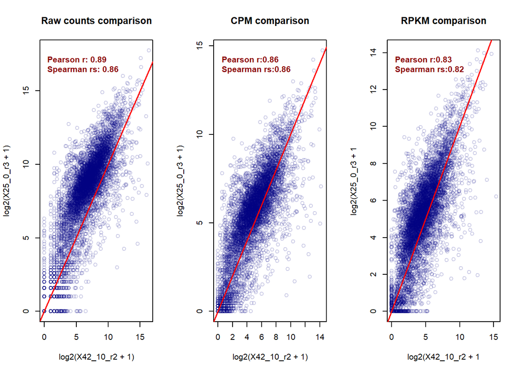

```r
test1_raw <- count_matrix[, "X25_0_r3"];
test2_raw <- count_matrix[, "X42_10_r2"];

test1_cpm <- cpm_matrix[, "X25_0_r3"];
test2_cpm <- cpm_matrix[, "X42_10_r2"];

test1_rpkm <- rpkm_matrix[, "X25_0_r3"];
test2_rpkm <- rpkm_matrix[, "X42_10_r2"];

par(mfrow = c(1,3))

plot(log2(test2_raw + 1), log2(test1_raw + 1),
     col = rgb(0, 0, 0.5, 0.2),
     main = "Raw counts comparison",
     xlab = "log2(X42_10_r2 + 1)",
     ylab = "log2(X25_0_r3 + 1)")
abline(a = 0, b = 1, col = "red", lwd = 1.5)

cor_p_raw <- cor(log2(test2_raw + 1), log2(test1_raw + 1), method = "pearson")
cor_s_raw <- cor(log2(test2_raw + 1), log2(test1_raw + 1), method = "spearman")

text(x = 0.5, y = max(log2(test1_raw + 1)) * 0.98,
     labels = paste0("Pearson r: ", round(cor_p_raw, 2),
                     "\nSpearman rs: ", round(cor_s_raw, 2)),
     adj = c(0, 1), col = "darkred", font = 2)

plot(log2(test2_cpm + 1), log2(test1_cpm + 1),
     col = rgb(0, 0, 0.5, 0.2),
     main = "CPM comparison",
     xlab = "log2(X42_10_r2 + 1)",
     ylab = "log2(X25_0_r3 + 1)")
abline(a = 0, b = 1, col = "red", lwd = 1.5)

cor_p_cpm <- cor(log2(test2_cpm + 1), log2(test1_cpm + 1), method = "pearson")
cor_s_cpm <- cor(log2(test2_cpm + 1), log2(test1_cpm + 1), method = "spearman")

text(x = 0.5, y = max(log2(test1_cpm + 1)) * 0.98,
     labels = paste0("Pearson r:", round(cor_p_cpm, 2),
                    "\nSpearman rs:", round(cor_s_cpm, 2)),
     adj = c(0,1), col = "darkred", font = 2)

plot(log2(test2_rpkm + 1), log2(test1_rpkm + 1),
     col = rgb(0, 0, 0.5, 0.2),
     main = "RPKM comparison",
     xlab = "log2(X42_10_r2 + 1",
     ylab = "log2(X25_0_r3 + 1")
abline(a = 0, b = 1, col = "red", lwd = 1.5)

cor_p_rpkm <- cor(log2(test2_rpkm + 1), log2(test1_rpkm + 1), method = "pearson")
cor_s_rpkm <- cor(log2(test2_rpkm + 1), log2(test1_rpkm + 1), method = "spearman")

text(x = 0.5, y = max(log2(test1_rpkm + 1)) * 0.98,
     labels = paste0("Pearson r:", round(cor_p_rpkm, 2),
                     "\nSpearman rs:", round(cor_s_rpkm, 2)),
     adj = c(0,1), col = "darkred", font = 2)
```

*Raw Counts:* Almost all points are above the diagonal. This shows – in comparison to the other scatterplots – the impact of technical artifacts. Statistically, the strong correlation (Pearson r = 0.89, Spearman rs = 0.86) reflects that the global expression profiles are highly similar, but the technical shift (asymmetry around the diagonal) is caused by the differing sequencing depths.

*CPM:* The data cloud is now centered around the diagonal line. This proves the success of the library size normalization, which was highly necessary because the raw counts of sample X25_0_r3 showed roughly double the sequencing reads compared to X42_10_r2. The correlation coefficients remain very high (r = 0.86, rs = 0.86), demonstrating that adjusting for library size centers the data without losing or distorting the underlying monotonic and linear relationships between the replicates.

*RPKM:* This plot incorporates an additional correction for gene length. The diagonal trend line remains consistent with the CPM plot, but individual gene positions shift vertically depending on their transcript length. The remaining outliers scattered away from the main diagonal cloud represent biologically meaningful differences, capturing the activation of the yeast’s heat-shock response and adaptation machinery. Interestingly, the correlation slightly drops here (r = 0.83, rs = 0.82). This marginal decrease is expected because RPKM penalizes longer transcripts, thereby removing artificial inflation and revealing the true biological variance, including specific outliers that respond to the heat shock.

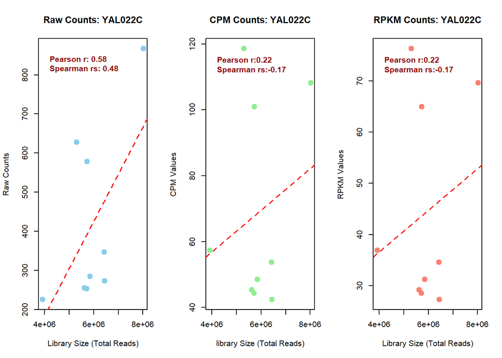

```r
selected_gene <- 465
gene_name <- rownames(count_matrix)[selected_gene]

gene_raw <- count_matrix[selected_gene, ]
gene_cpm <- cpm_matrix[selected_gene, ]
gene_rpkm <- rpkm_matrix[selected_gene, ]

par(mfrow = c(1,3))

plot(library_sizes, gene_raw,
     col = "skyblue",
     main = paste("Raw Counts:", gene_name),
     xlab = "Library Size (Total Reads)",
     ylab = "Raw Counts",
     cex = 1.5,
     pch = 19)
abline(lm(gene_raw ~ library_sizes), col = "red", lwd = 1.5, lty = 2)

cor_p_d1 <- cor(library_sizes, gene_raw, method = "pearson")
cor_s_d1 <- cor(library_sizes, gene_raw, method = "spearman")

text(x = 4200000, y = max(gene_raw) * 0.98,
     labels = paste0("Pearson r: ", round(cor_p_d1, 2),
                     "\nSpearman rs: ", round(cor_s_d1, 2)),
     adj = c(0, 1), col = "darkred", font = 2)

plot(library_sizes, gene_cpm,
     col = "lightgreen",
     main = paste("CPM Counts:", gene_name),
     xlab = "library Size (Total Reads)",
     ylab = "CPM Values",
     cex = 1.5,
     pch = 19)
abline(lm(gene_cpm ~ library_sizes), col = "red", lwd = 1.5, lty = 2)

cor_p_d2 <- cor(library_sizes, gene_cpm, method = "pearson")
cor_s_d2 <- cor(library_sizes, gene_cpm, method = "spearman")

text(x = 4200000, y = max(gene_cpm) * 0.98,
     labels = paste0("Pearson r:", round(cor_p_d2, 2),
                    "\nSpearman rs:", round(cor_s_d2, 2)),
     adj = c(0, 1), col = "darkred", font = 2)

plot(library_sizes, gene_rpkm,
     col = "salmon",
     main = paste("RPKM Counts:" , gene_name),
     xlab = "Library Size (Total Reads)",
     ylab = "RPKM Values",
     cex = 1.5,
     pch = 19)
abline(lm(gene_rpkm ~ library_sizes), col = "red", lwd = 1.5, lty = 2)

cor_p_d3 <- cor(library_sizes, gene_rpkm, method = "pearson")
cor_s_d3 <- cor(library_sizes, gene_rpkm, method = "spearman")

text(x = 4200000, y = max(gene_rpkm) * 0.98,
     labels = paste0("Pearson r:", round(cor_p_d3, 2),
                    "\nSpearman rs:", round(cor_s_d3, 2)),
     adj = c(0, 1), col = "darkred", font = 2)
```

The general purpose of this plot is to evaluate the dependency of gene expression values on the technical sequencing depth (library size) at a single-feature level. By comparing Raw Counts to CPM and RPKM, it visualizes whether the normalization successfully eliminates technical scaling artifacts. In an ideal control scenario, a flat regression line in CPM/RPKM proves that the library size effect was removed, leaving any remaining variance to be driven solely by true biological differences or replicate noise. While the trendline for YAL022C suggests a positive correlation between library size and expression, a closer look at the individual sample distribution reveals that this trend is heavily driven by two leverage points: the over-sequenced control sample X25_0_r3 on the far right and the under-sequenced heat sample X42_10_r2 on the far left. The remaining samples in the center show high variance, indicating that this specific gene might not be strongly differentially expressed under heat stress, but rather subject to stochastic noise and replicate variation. This visual interpretation is explicitly supported by the correlation metrics: > * In the Raw Counts plot, we observe a clear positive linear relationship (Pearson r = 0.58, Spearman rs = 0.48), which reflects the uncorrected technical influence of sequencing depth on this gene.

Upon CPM and RPKM normalization, the metrics shift significantly (Pearson r = 0.22, Spearman rs = -0.17). The drop in the Pearson coefficient shows that adjusting for library size breaks down the artificial linear dependency. More importantly, the Spearman rank correlation flips to a slight negative value (-0.17). This mathematically confirms that the overall monotonic trend has been broken and that the seemingly positive regression line is an artifact purely sustained by the two extreme leverage samples at the boundaries.

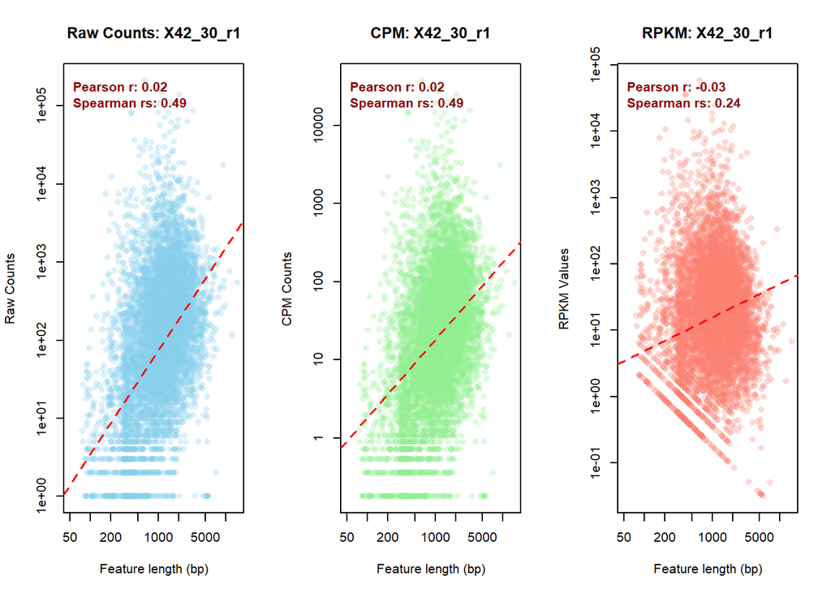

```r
selected_sample <- 7
sample_name <- colnames(count_matrix)[selected_sample]

sample_raw <- count_matrix[, selected_sample]
sample_cpm <- cpm_matrix[, selected_sample]
sample_rpkm <- rpkm_matrix[, selected_sample]

par(mfrow = c(1,3))

plot(genes_length, sample_raw,
     col = rgb(135/255, 206/255, 235/255, 0.3),
     pch = 16,
     main = paste("Raw Counts:", sample_name),
     xlab = "Feature length (bp)",
     ylab = "Raw Counts",
     log = "xy")
abline(lm(log10(sample_raw + 1) ~ log10(genes_length)), col = "red", lwd = 1.5, lty = 2)

cor_p_e1 <- cor(genes_length, sample_raw, method = "pearson")
cor_s_e1 <- cor(genes_length, sample_raw, method = "spearman")

text(x = 55, y = max(sample_raw) * 0.98,
     labels = paste0("Pearson r: ", round(cor_p_e1, 2),
                     "\nSpearman rs: ", round(cor_s_e1, 2)),
     adj = c(0, 1), col = "darkred", font = 2)

plot(genes_length, sample_cpm,
     col = rgb(144/255, 238/255, 144/255, 0.3),
     pch = 16,
     main = paste("CPM:", sample_name),
     xlab = "Feature length (bp)",
     ylab = "CPM Counts",
     log = "xy")
abline(lm(log10(sample_cpm + 1) ~ log10(genes_length)), col = "red", lwd = 1.5, lty = 2)

cor_p_e2 <- cor(genes_length, sample_cpm, method = "pearson")
cor_s_e2 <- cor(genes_length, sample_cpm, method = "spearman")

text(x = 55, y = max(sample_cpm) * 0.98,
     labels = paste0("Pearson r: ", round(cor_p_e2, 2),
                     "\nSpearman rs: ", round(cor_s_e2, 2)),
     adj = c(0, 1), col = "darkred", font = 2)

plot(genes_length, sample_rpkm,
     col = rgb(250/255, 128/255, 114/255, 0.3),
     pch = 16,
     main = paste("RPKM:", sample_name),
     xlab = "Feature length (bp)",
     ylab = "RPKM Values",
     log = "xy")
abline(lm(log10(sample_rpkm + 1) ~ log10(genes_length)), col = "red", lwd = 1.5, lty = 2)

cor_p_e3 <- cor(genes_length, sample_rpkm, method = "pearson")
cor_s_e3 <- cor(genes_length, sample_rpkm, method = "spearman")

text(x = 55, y = max(sample_rpkm) * 0.98,
     labels = paste0("Pearson r: ", round(cor_p_e3, 2),
                     "\nSpearman rs: ", round(cor_s_e3, 2)),
     adj = c(0, 1), col = "darkred", font = 2)
```

*Raw Counts & CPM:* Both plots exhibit a strong positive correlation between feature length and expression levels. This directly visualizes the technical length bias in RNA-seq data: longer genes mechanically accumulate more reads during sequencing. Since CPM only normalizes for library size, it completely fails to remove this length-dependent artifact.The drastic discrepancy between the correlation metrics explicitly highlights this issue: While the Pearson correlation coefficient is virtually zero (Pearson r = 0.02), suggesting no relationship at all, the Spearman rank correlation reveals a substantial positive trend (Spearman rs = 0.49). This occurs because the untransformed dataset is highly skewed, with a few massive gene outliers dominating the linear calculation. While Pearson fails to capture this due to its strict assumption of linearity on raw values, Spearman correctly identifies the severe, non-linear length bias.